# DATA SCIENCE LATAM

### Subconjunto de la Serie de Tiempo

Las series de tiempo pueden contener grandes observaciones que abarcan muchos años. Es posible que desee trabajar en una parte específica de series de tiempo; por ejemplo, encontrar las ventas de los primeros 3 meses, o las ventas de los últimos 3 meses, o las ventas entre 2007 y 2009, y así sucesivamente. Esta sección explorará varias formas de obtener los datos o subconjuntos requeridos o deseados de la serie de tiempo.

```r
# La funcion head permite extraer datos de la parte inicial del conjuntos de datos.
head(my_series)
#[1] 2914 2962 2678 3025 2694 3437
```

```r
# La funcion tail permite extraer datos de la parte final del conjuntos de datos.
tail(my_series)
#[1] 3562 3682 3251 3732 2873 2533
```

```r
# tambien se puede extraer los ultimos 20 valores del conjunto de datos
tail(my_series, 20)
#[1] 2793 2776 3986 2540 2930 2589 2815 3746 3027 3639 3273 3246 2955 3097 3562 3682 3251 3732 2873 2533
```

En series de tiempo, es posible que desee extraer datos en una forma tal como extraer los últimos 3 meses de datos o 3 semanas de datos, y así sucesivamente. Será tedioso con head y con tail encontrar el número exacto. Los paquetes **zoo y xts** proporciona las funciones **first** y **last** que se pueden utilizar para extraer datos de la serie de tiempo de la manera requerida. Con esta función, puede extraer datos claramente durante 3 meses, 3 años, etc.

```r
library(xts)
first(my_series) # predeterminado es el primer valor
last(my_series) # predeterminado es el ultimo valor
# extrae los valores de los 3 primeros meses de mi serie
first(my_series, "3 months")
# extrae los valores de los 3 primeros años de mi serie
first(my_series, "3 years")
# extrae los valores de los 3 ultimos meses de mi serie
last(my_series, "3 months")
# extrae los valores de los 3 ultimos años de mi serie
last(my_series, "3 years")
#extraer datos desde el año inicial 2009 hasta el año 2013.
```

Para obtener el subconjunto en forma de rango, se utiliza la función **window**; por ejemplo; extraer datos desde el año inicial 2011 hasta el año 2013.

```r
window(my_series, start=c(2011,1), end=c(2013,12))
```

```r
#     Jan  Feb  Mar  Apr  May  Jun  Jul  Aug  Sep  Oct  Nov  Dec
#2011 2914 2962 2678 3025 2694 3437 3641 3822 3752 3767 3537 3897
#2012 3164 3101 3208 3510 3614 3452 2847 3516 3878 3339 2525 3018
#2013 3949 2710 3431 3092 3054 2872 3343 3666 3043 2989 3404 3436
```

# 4. Patrones de series de tiempo

Al describir estas series de tiempo, hemos utilizado palabras como "tendencia" y "estacional" que deben definirse con más cuidado.

### Tendencia

Existe una tendencia cuando hay un aumento o disminución a largo plazo en los datos. No tiene que ser lineal. A veces nos referiremos a una tendencia como "dirección cambiante", cuando podría pasar de una tendencia creciente a una tendencia decreciente. Hay una tendencia en los datos de ventas de medicamentos antidiabéticos que se muestran en la Figura:

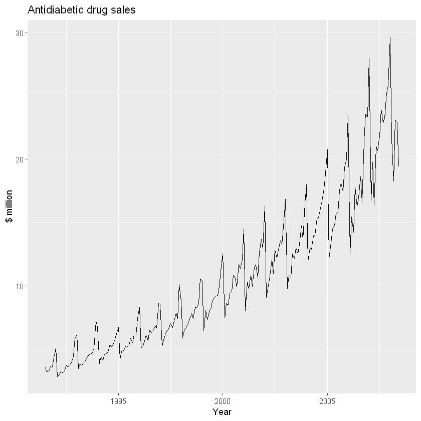

```r
autoplot(a10) +
  ggtitle("Antidiabetic drug sales") +
  ylab("$ million") +
  xlab("Year")
```

### Estacional

Un patrón estacional ocurre cuando una serie de tiempo se ve afectada por factores estacionales como la época del año o el día de la semana. La estacionalidad es siempre de una frecuencia fija y conocida. Las ventas mensuales de medicamentos antidiabéticos anteriores muestran la estacionalidad que es inducida en parte por el cambio en el costo de los medicamentos al final del año calendario.

### Cíclico

Un ciclo ocurre cuando la exhibición de datos sube y baja y no son de una frecuencia fija. Estas fluctuaciones generalmente se deben a las condiciones económicas, y a menudo están relacionadas con el "ciclo económico". La duración de estas fluctuaciones suele ser de al menos 2 años.

Muchas personas confunden el **comportamiento cíclico** con el **comportamiento estacional**, pero en realidad son bastante diferentes. Si las fluctuaciones no son de una frecuencia fija, entonces son cíclicas; Si la frecuencia no cambia y está asociada con algún aspecto del calendario, entonces el patrón es estacional. En general, la duración promedio de los ciclos es más larga que la duración de un patrón estacional, y las magnitudes de los ciclos tienden a ser más variables que las magnitudes de los patrones estacionales.

Muchas series de tiempo incluyen tendencia, ciclos y estacionalidad. **Al elegir un método de pronóstico, primero tendremos que identificar los patrones de series de tiempo en los datos**, y luego elegir un método que pueda capturar los patrones correctamente.

Los ejemplos en la siguiente Figura muestran diferentes combinaciones de los componentes anteriores.

[figure not shown]

1. Las ventas mensuales de viviendas (arriba a la izquierda) muestran una fuerte estacionalidad dentro de cada año, así como también un fuerte comportamiento cíclico con un período de aproximadamente 6-10 años. No hay una tendencia aparente en los datos durante este período.
1. Los contratos de letras del tesoro de los Estados Unidos (arriba a la derecha) muestran resultados del mercado de Chicago durante 100 días de negociación consecutivos en 1981. Aquí no hay estacionalidad, sino una tendencia a la baja evidente. Posiblemente, si tuviéramos una serie mucho más larga, veríamos que esta tendencia a la baja es en realidad parte de un ciclo largo, pero cuando se ve en solo 100 días, parece ser una tendencia.
1. La producción trimestral de electricidad en Australia (abajo a la izquierda) muestra una fuerte tendencia creciente, con una fuerte estacionalidad. No hay evidencia de ningún comportamiento cíclico aquí.
1. El cambio diario en el precio de cierre de las acciones de Google (abajo a la derecha) **no tiene tendencia, estacionalidad o comportamiento cíclico**. Hay fluctuaciones aleatorias que no parecen ser muy predecibles, y **no hay patrones fuertes que ayuden a desarrollar un modelo de pronóstico**.

# 5. Graficos estacionales

Una gráfica estacional es similar a una gráfica temporal, excepto que los datos se grafican contra las "estaciones" individuales en las que se observaron los datos. A continuación se muestra un ejemplo que muestra las ventas de medicamentos antidiabéticos.

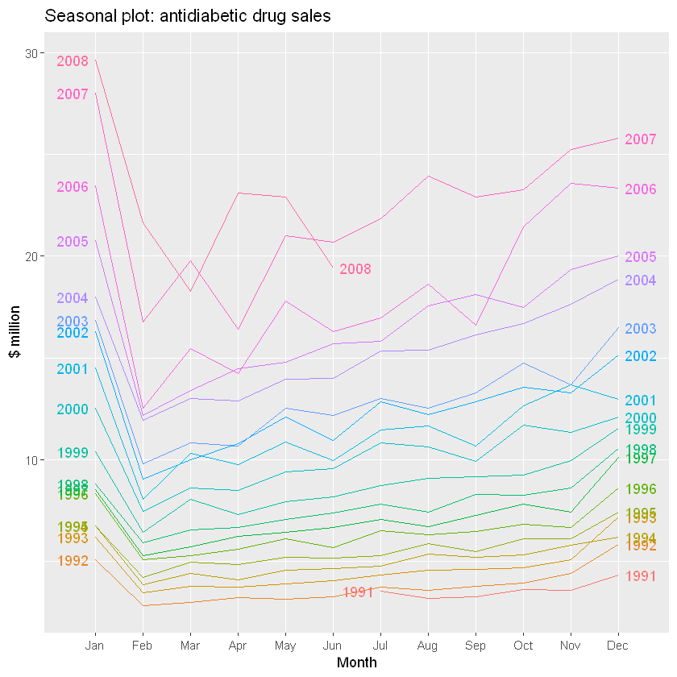

```r
ggseasonplot(a10, year.labels=TRUE, year.labels.left=TRUE) +
  ylab("$ million") +
  ggtitle("Seasonal plot: antidiabetic drug sales")
```

Estos son exactamente los mismos datos que se mostraron anteriormente, pero ahora los datos de cada temporada se superponen. Un gráfico estacional permite que el patrón estacional subyacente se vea más claramente, y es especialmente útil para identificar años en los que el patrón cambia.

En este caso, está claro que hay un gran salto en las ventas en enero de cada año. En realidad, estas son probablemente ventas a fines de diciembre, ya que los clientes almacenan antes del final del año calendario, pero las ventas no se registran en el gobierno hasta una o dos semanas después. El gráfico también muestra que hubo un número inusualmente pequeño de ventas en marzo de 2008 (la mayoría de los otros años muestran un aumento entre febrero y marzo). El pequeño número de ventas en junio de 2008 probablemente se deba al recuento incompleto de las ventas en el momento en que se recopilaron los datos.

Una variación útil en la gráfica estacional utiliza coordenadas polares. La configuración polar=TRUE hace que el eje de la serie temporal sea circular en lugar de horizontal, como se muestra a continuación.

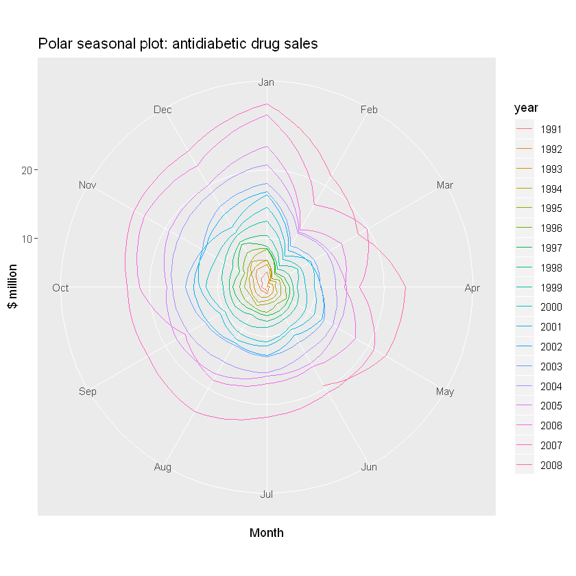

```r
ggseasonplot(a10, polar=TRUE) +
  ylab("$ million") +
  ggtitle("Polar seasonal plot: antidiabetic drug sales")
```

## 6. Gráficos de subseries estacionales

Una gráfica alternativa que enfatiza los patrones estacionales es donde los datos para cada temporada se recopilan juntos en mini gráficas de tiempo separadas.

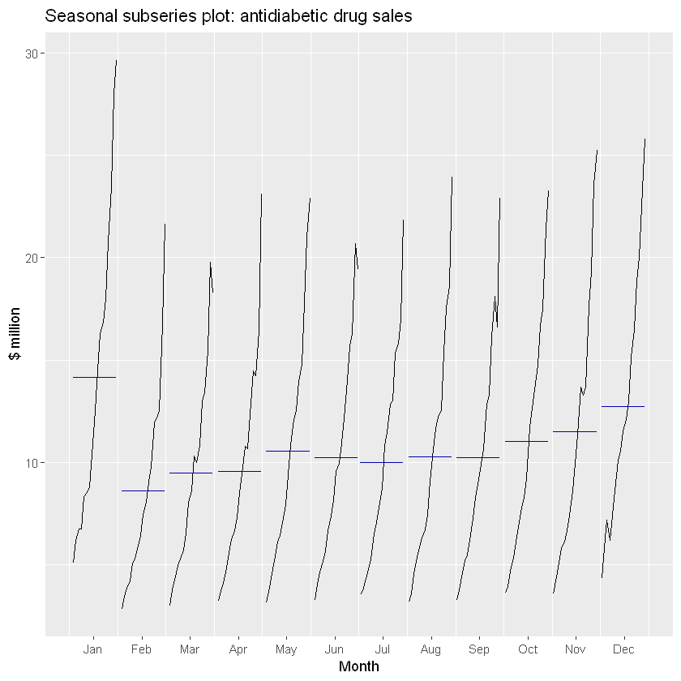

```r
ggsubseriesplot(a10) +
  ylab("$ million") +
  ggtitle("Seasonal subseries plot: antidiabetic drug sales")
```

Las líneas horizontales indican las medias para cada mes. Esta forma de diagrama permite ver claramente el patrón estacional subyacente y también muestra los cambios en la estacionalidad a lo largo del tiempo. Es especialmente útil para identificar cambios dentro de estaciones particulares. En este ejemplo, la trama no es particularmente reveladora; pero en algunos casos, esta es la forma más útil de ver los cambios estacionales a lo largo del tiempo.

## 7. Diagramas de dispersión (Scatterplots)

Podemos estudiar la relación entre la demanda y la temperatura trazando una serie contra la otra. La Demanda de electricidad cada media hora (en Gigavatios) y temperatura (en grados Celsius), para 2014 en Victoria, Australia. Las temperaturas son para Melbourne, la ciudad más grande de Victoria, mientras que los valores de la demanda son para todo el estado.

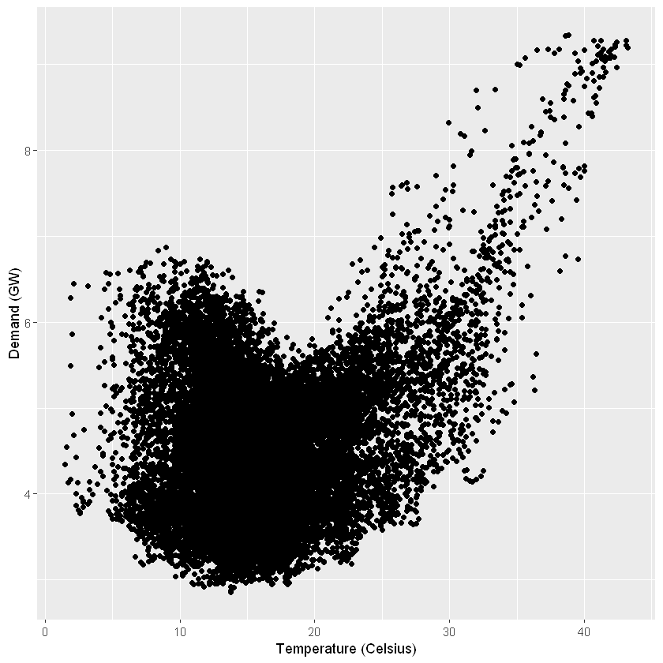

```r
#FIGURA A

qplot(Temperature, Demand, data=as.data.frame(elecdemand)) +
  ylab("Demand (GW)") + xlab("Temperature (Celsius)")
```

Este diagrama de dispersión nos ayuda a visualizar la relación entre las variables. Está claro que la alta demanda ocurre cuando las temperaturas son altas debido al efecto del aire acondicionado. Pero también hay un efecto de calentamiento, donde la demanda aumenta para temperaturas muy bajas.

#### Correlación

Es común calcular coeficientes de correlación para medir la fuerza de la relación entre dos variables. La correlación entre variables x e y está dado por

$$r = \frac{\sum (x_{t} - \bar{x})(y_{t}-\bar{y})}{\sqrt{\sum(x_{t}-\bar{x})^2}\sqrt{\sum(y_{t}-\bar{y})^2}}$$

El valor de r se encuentra entre 1 y -1, valores negativos que indican una relación negativa y valores positivos que indican una relación positiva. Los gráficos en la siguiente Figura (B) muestran ejemplos de conjuntos de datos con diferentes niveles de correlación.

[figure not shown]

El coeficiente de correlación solo mide la fuerza de la relación lineal, y a veces puede ser engañoso. Por ejemplo, la correlación para la demanda de electricidad y los datos de temperatura que se muestran en la Figura A es 0.28.

Todas las gráficas de a continuación tienen coeficientes de correlación de 0.82, pero tienen relaciones muy diferentes. Esto muestra lo importante que es mirar las gráficas de los datos y no simplemente confiar en los valores de correlación.

[figure not shown]

## 8. Matrices de diagrama de dispersión

Cuando hay varias variables predictoras potenciales, es útil trazar cada variable frente a otra variable. Considere las cinco series de tiempo que se muestran en la Figura siguiente, que muestran los números de visitantes trimestrales para cinco regiones de Nueva Gales del Sur, Australia.

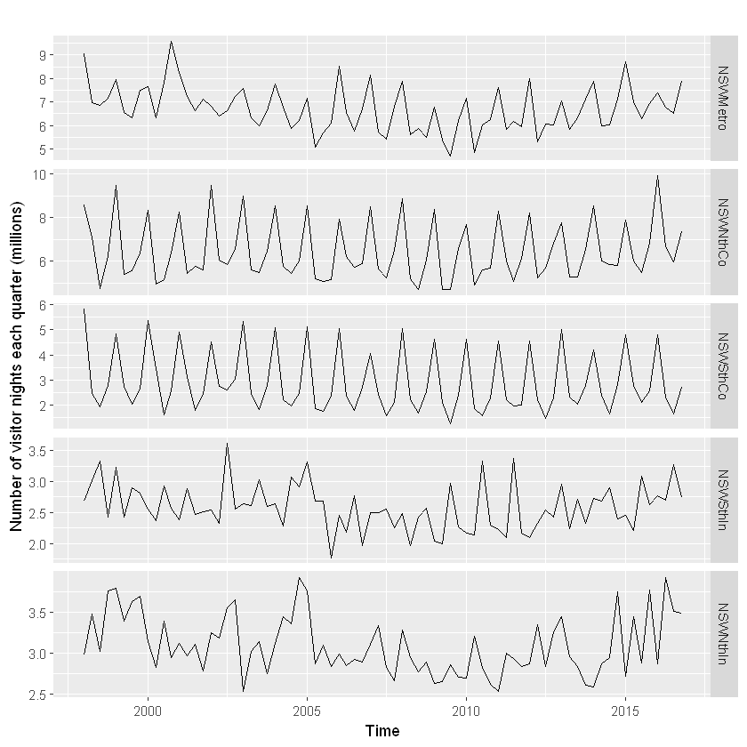

```r
autoplot(visnights[,1:5], facets=TRUE) +
  ylab("Number of visitor nights each quarter (millions)")
```

Para ver las relaciones entre estas cinco series de tiempo, podemos trazar cada serie de tiempo contra las otras. Estas parcelas se pueden organizar en una matriz de diagrama de dispersión, como se muestra en la Figura siguiente. (Este diagrama requiere el paquete GGally).

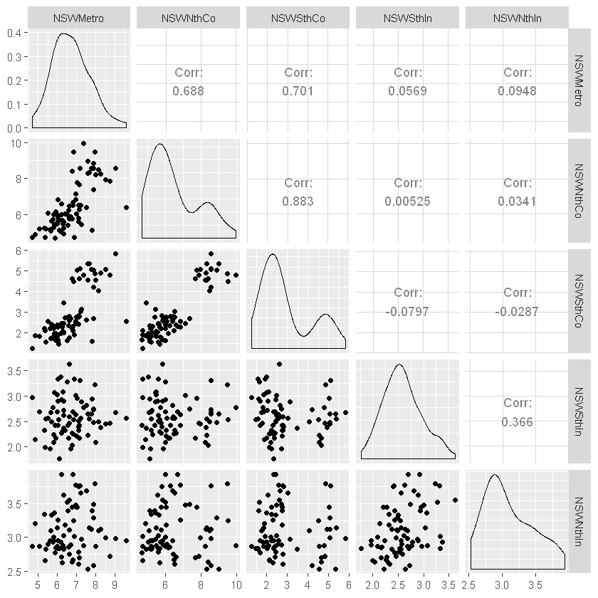

```r
GGally::ggpairs(as.data.frame(visnights[,1:5]))
```

En la versión predeterminada, las correlaciones se muestran en la mitad superior derecha del gráfico, mientras que los diagramas de dispersión se muestran en la mitad inferior. En la diagonal se muestran diagramas de densidad.

El valor de la matriz de diagrama de dispersión es que permite una vista rápida de las relaciones entre todos los pares de variables. En este ejemplo, la segunda columna de parcelas muestra que existe una fuerte relación positiva entre los visitantes de la costa norte de NSW y los visitantes de la costa sur de NSW, pero no hay una relación detectable entre los visitantes de la costa norte de NSW y los visitantes del interior del sur de NSW. Los valores atípicos también se pueden ver. Hay un trimestre inusualmente alto para la región metropolitana de NSW, que corresponde a los Juegos Olímpicos de Sydney 2000. Esto se ve más fácilmente en las dos primeras graficas en la columna izquierda de la Figura, donde el valor más grande para NSW Metro está separado de la nube principal de observaciones.

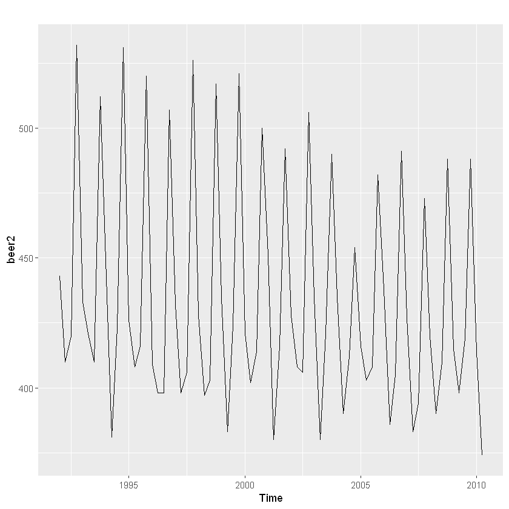

```r
beer2 <- window(ausbeer, start=1992)
autoplot(beer2)
```

## 9. Graficas Lag

La figura siguiente muestra diagramas de dispersión de la producción trimestral de cerveza australiana, donde el eje horizontal muestra valores rezagados (**lagged values**) de las series de tiempo. Cada grafica muestra $y_{t}y_{t-k}$

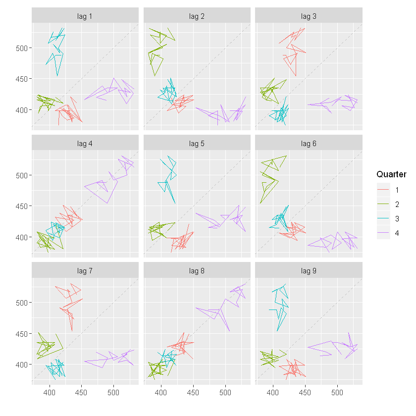

```r
beer2 <- window(ausbeer, start=1992)
gglagplot(beer2)
```

Aquí los colores indican el trimestre de la variable en el eje vertical. Las líneas conectan puntos en orden cronológico. **La relación es muy positiva en los rezagos 4 y 8, lo que refleja la fuerte estacionalidad en los datos**. La relación negativa observada para los rezagos 2 y 6 ocurre porque los picos (en Q4) se trazan contra los canales (en Q2).

La función window() utilizada aquí es muy útil cuando se extrae una parte de una serie de tiempo. En este caso, hemos extraído los datos ausbeer a partir de 1992.

**Graficando con funciones bases de R**

```r
set.seed(123)
sales = sample(400:10000, 72, replace= TRUE)
my_newseries = ts(sales, start=c(2011,1), end=c(2016,12), frequency = 12)
```

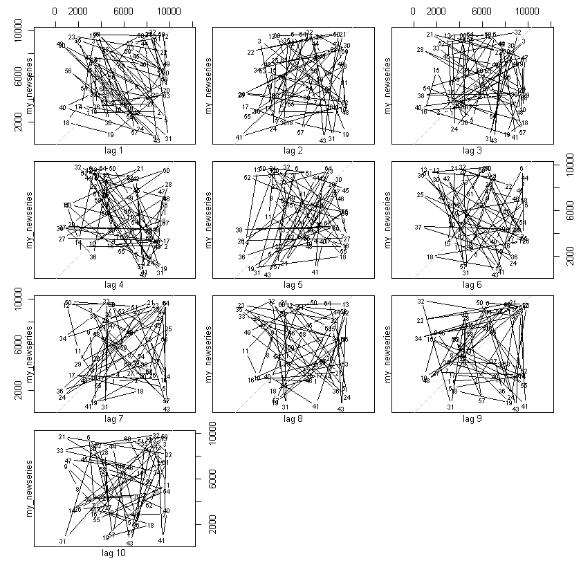

```r
# Grafica para los retrasos 1 a 10

lag.plot(my_newseries, lags=10)

# La autocorrelación mide la relación lineal entre valores rezagados de una serie de tiempo.
# Por lo que observará que en my_newseries no hay cierta autocorrelación
# Las líneas conectan puntos en orden cronológico.
```

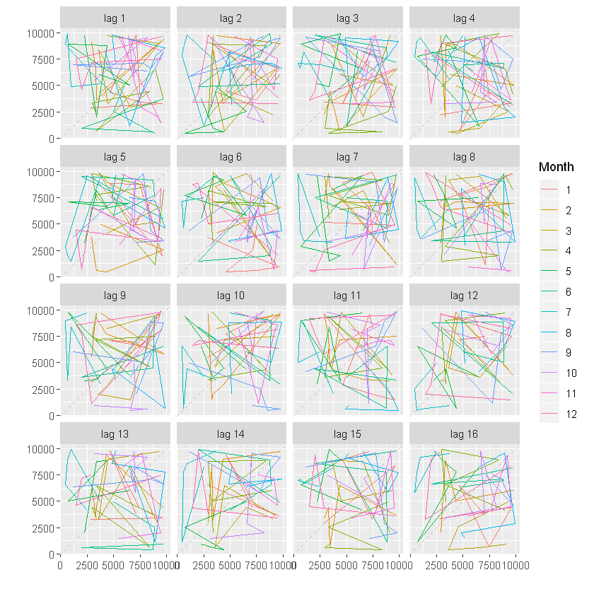

```r
# Otra forma de trazar la correlacion es con la funcion gglagplot
gglagplot(my_newseries)
```

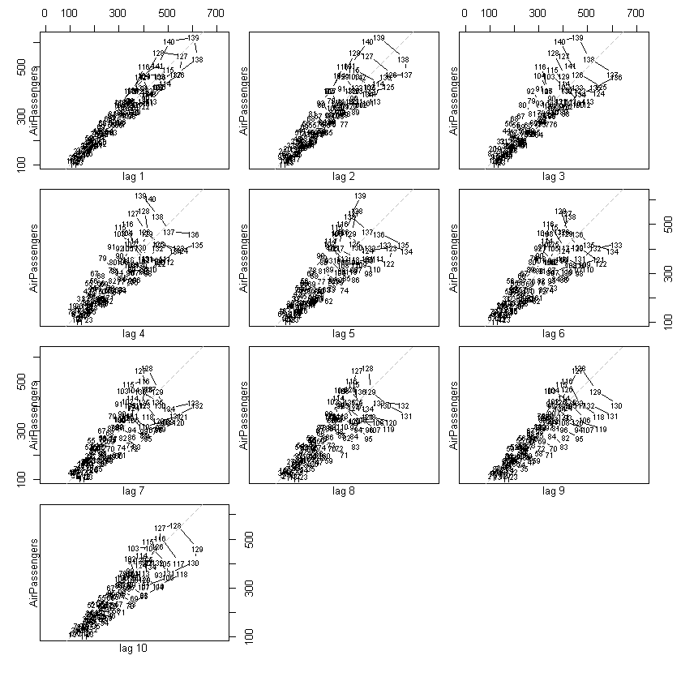

```r
# Grafica para los retrasos 1 a 10
lag.plot(AirPassengers, lags=10)
```

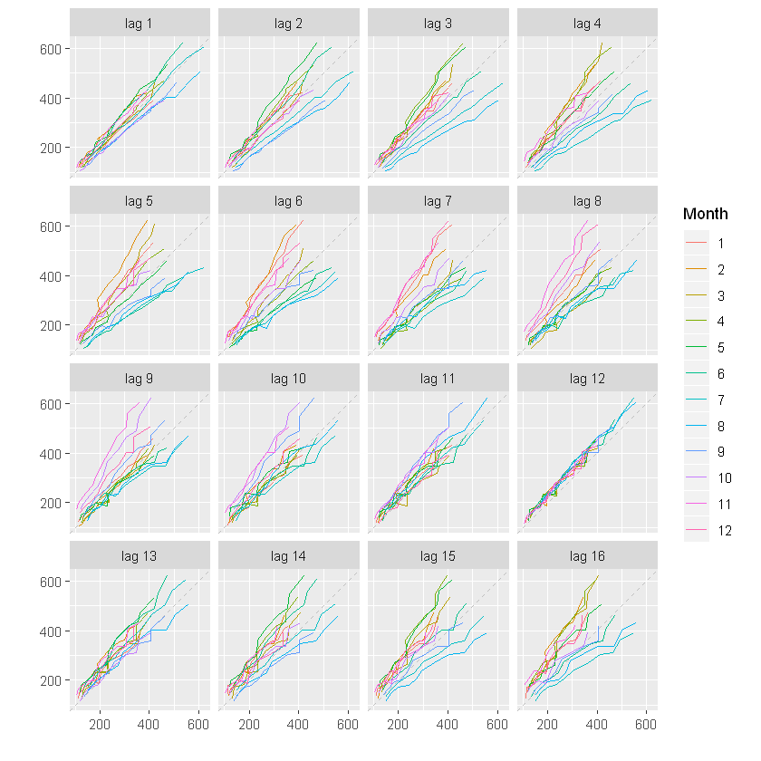

```r
gglagplot(AirPassengers)
```

## 10. Autocorrelación y gráfica ACF

Así como la correlación mide el alcance de una relación lineal entre dos variables, **la autocorrelación mide la relación lineal entre valores rezagados de una serie de tiempo**.

Hay varios coeficientes de autocorrelación, correspondientes a cada panel en el diagrama de Lag. Por ejemplo, $(r_ {1})$ mide la relación entre $(y_{t})$ y $(y_{t-1})$, $(r_{2})$ mide la relación entre $(y_{t})$ y $(y_{t-2})$ , y así sucesivamente.

El valor de $r_{k}$ se puede escribir como:

$$r_{k} = \frac{\sum\limits_{t=k+1}^T (y_{t}-\bar{y})(y_{t-k}-\bar{y})} {\sum\limits_{t=1}^T (y_{t}-\bar{y})^2}$$

donde $T$ es La longitud de la serie temporal.

Los primeros nueve coeficientes de autocorrelación para los datos de producción de cerveza se dan en la siguiente tabla.

[figure not shown]

Los coeficientes de autocorrelación se trazan para mostrar la función de autocorrelación o ACF. La trama también se conoce como un correlograma.

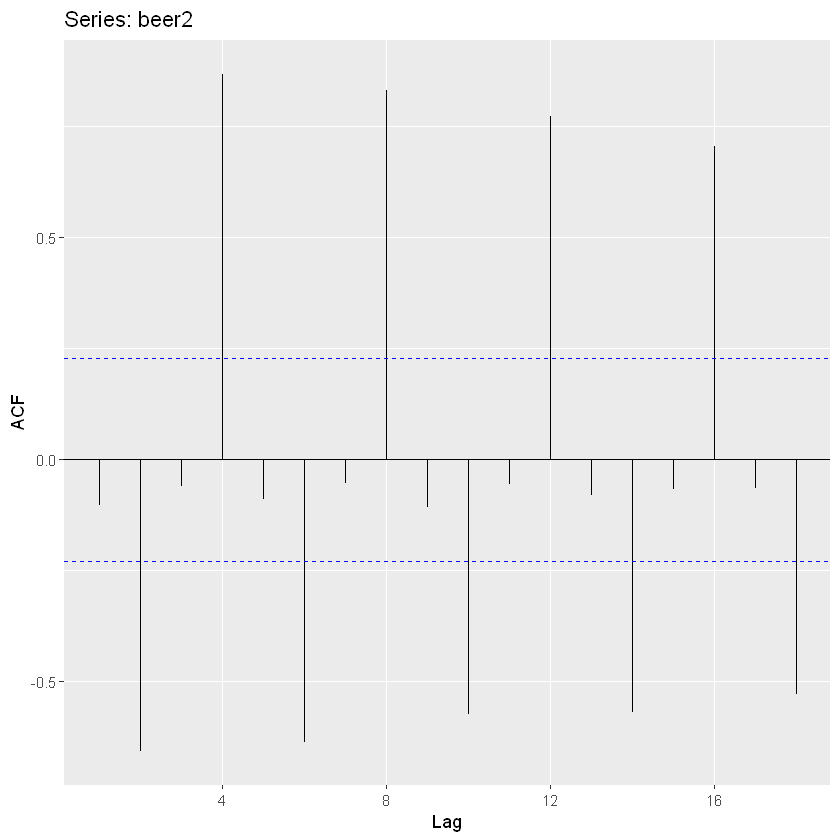

```r
ggAcf(beer2)
```

En este gráfico:

r4 es más alto que para los otros rezagos. Esto se debe al patrón estacional en los datos: los picos tienden a estar separados por cuatro trimestres y los canales tienden a estar separados por cuatro trimestres.

r2 es más negativo que para los otros rezagos porque los canales tienden a estar dos trimestres detrás de los picos.

Las líneas azules discontinuas indican si las correlaciones son significativamente diferentes de cero. Estos se explican en la seccion **RUIDO BLANCO**

**Graficando acf con la funcion base de R**

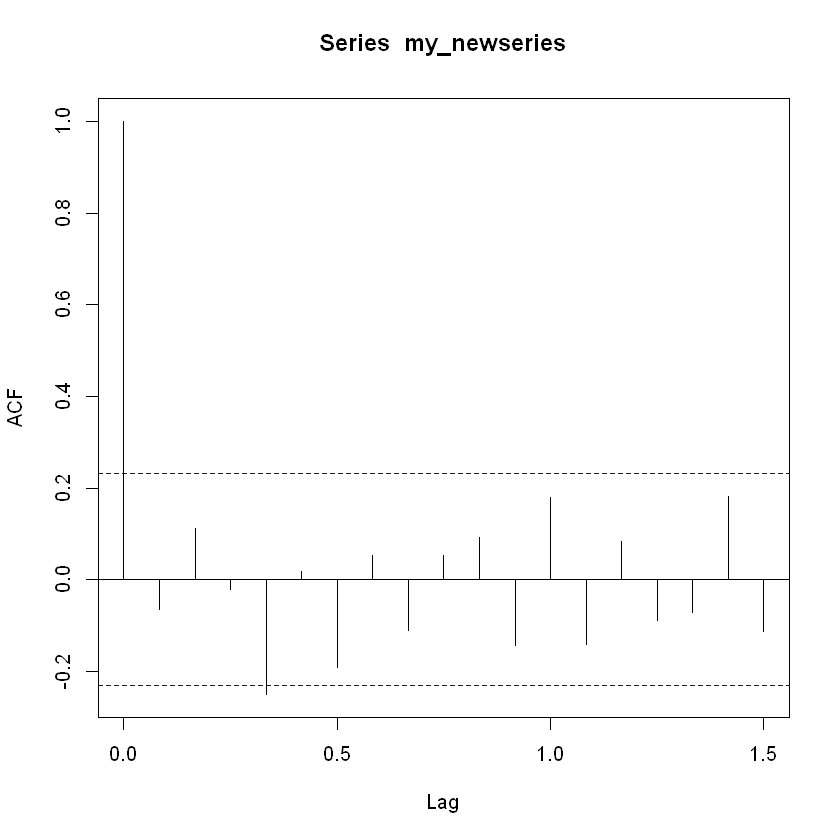

```r
# Grafica de Autocorrelación de my_newseries

acf(my_newseries)
# Los coeficientes de autocorrelación están cerca de 0
```

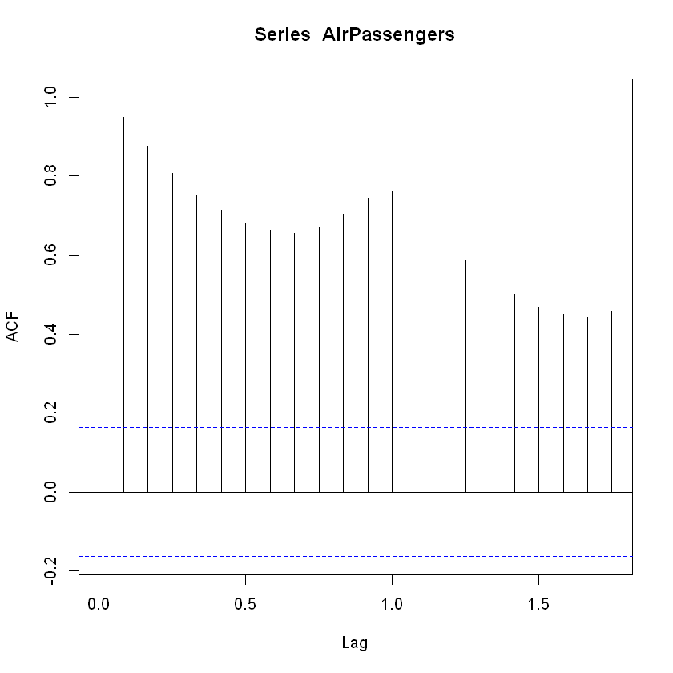

```r
acf(AirPassengers)
```

## Tendencia y estacionalidad en graficas ACF

Cuando los datos tienen una **tendencia**, las **autocorrelaciones** para **pequeños rezagos tienden a ser grandes y positivas** porque las observaciones cercanas en el tiempo también son cercanas en tamaño. Por lo tanto, el ACF de las series temporales con tendencia tiende a tener valores positivos que disminuyen lentamente a medida que aumentan los retrasos.

Cuando los datos son **estacionales**, las autocorrelaciones serán mayores para los rezagos estacionales (en múltiplos de la frecuencia estacional) que para otros rezagos.

Cuando los datos tienen tendencia y son estacionales, verá una combinación de estos efectos. La serie mensual de demanda de electricidad australiana representada en la Figura de a continuacion muestra tanto la tendencia como la estacionalidad. Su ACF se muestra en la Figura posterior.

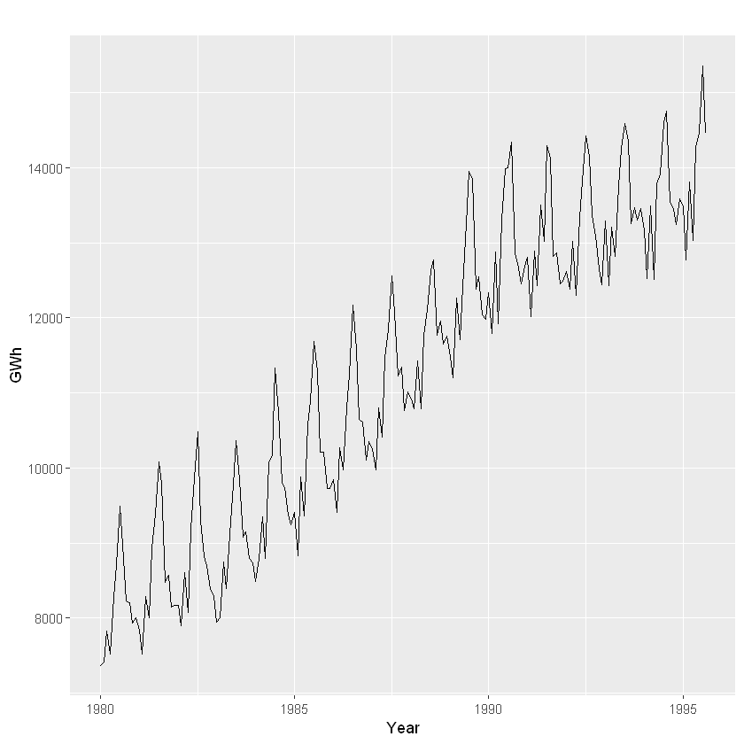

```r
aelec <- window(elec, start=1980)
autoplot(aelec) + xlab("Year") + ylab("GWh")
```

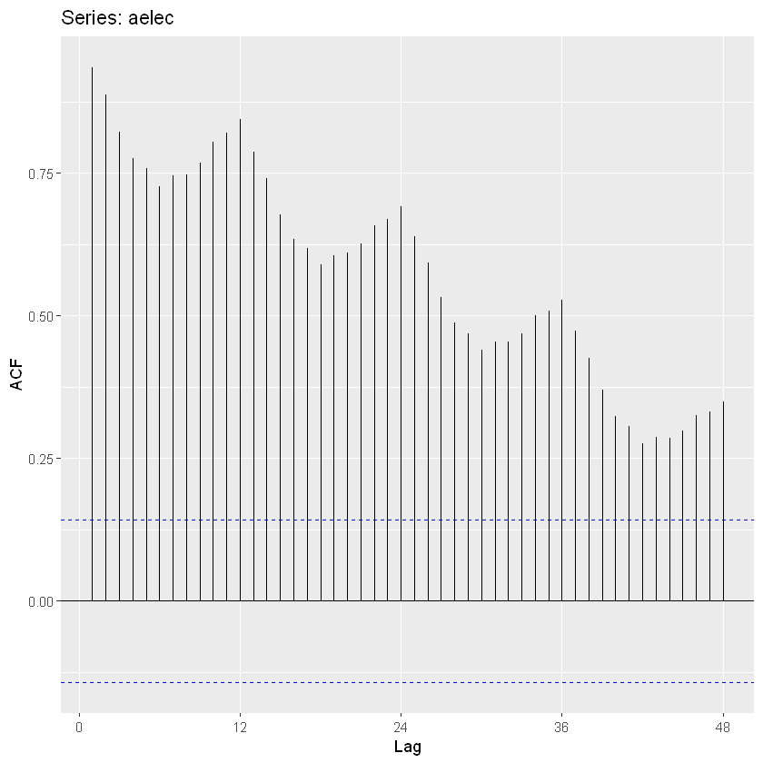

```r
ggAcf(aelec, lag=48)
```

La lenta disminución en el ACF a medida que aumentan los retrasos se debe a la tendencia, mientras que la forma "onduleada" se debe a la estacionalidad.

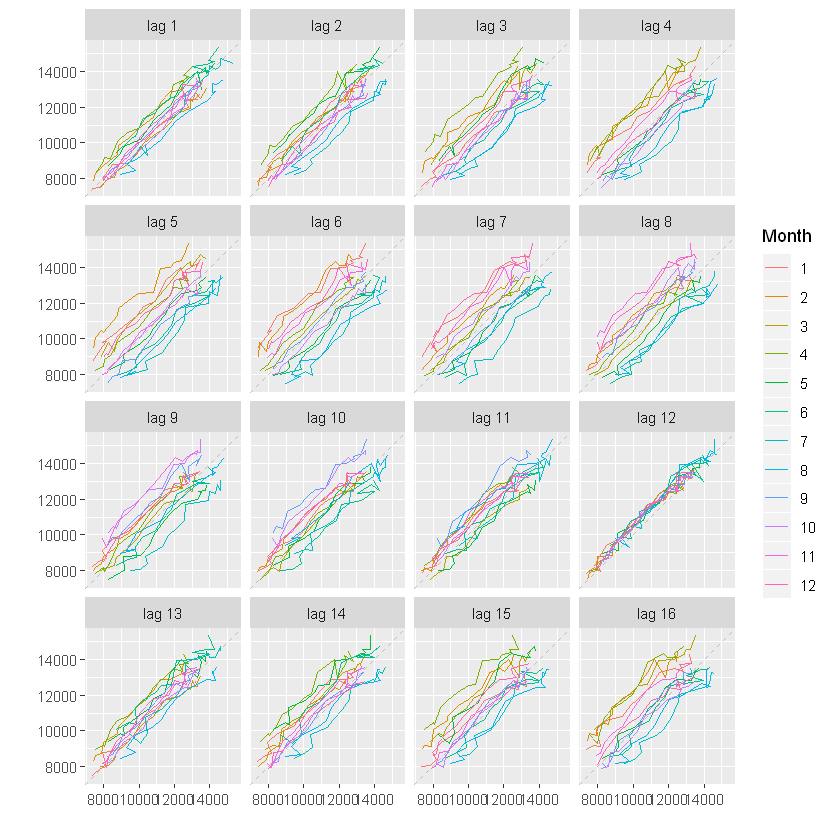

```r
gglagplot(aelec)
```

## 11. Ruido blanco

Las series de tiempo que no muestran autocorrelación se llaman ruido blanco. La figura siguiente da un ejemplo de una serie de ruido blanco.

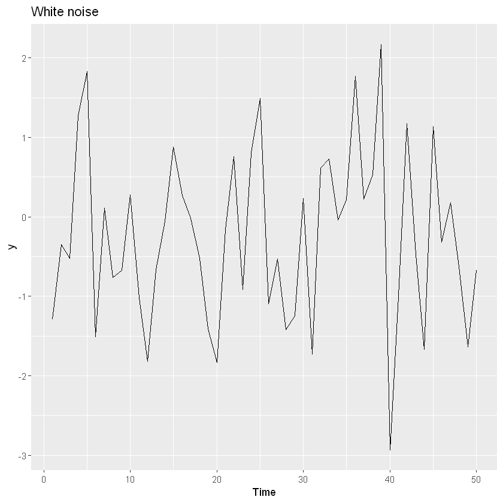

```r
set.seed(30)
y <- ts(rnorm(50))
autoplot(y) + ggtitle("White noise")
```

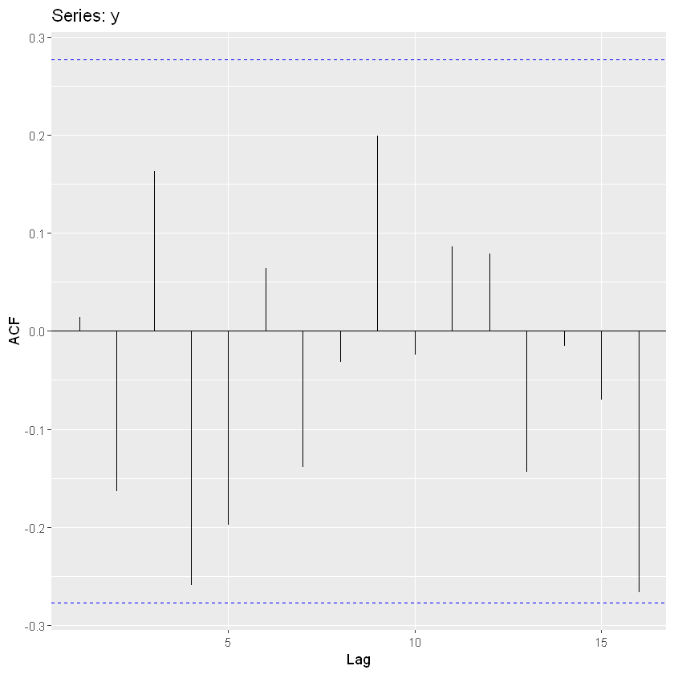

```r
ggAcf(y)
```

Para las series de ruido blanco, esperamos que cada autocorrelación sea cercana a cero. Por supuesto, no serán exactamente iguales a cero ya que hay alguna variación aleatoria. Para una serie de ruido blanco, esperamos que el 95% de los picos en el ACF se encuentren dentro de: $\pm 2/\sqrt{T}$

En este ejemplo $\pm 2/\sqrt{50} = \pm 0.28$ Todos los coeficientes de autocorrelación se encuentran dentro de estos límites, lo que confirma que los datos son ruido blanco.

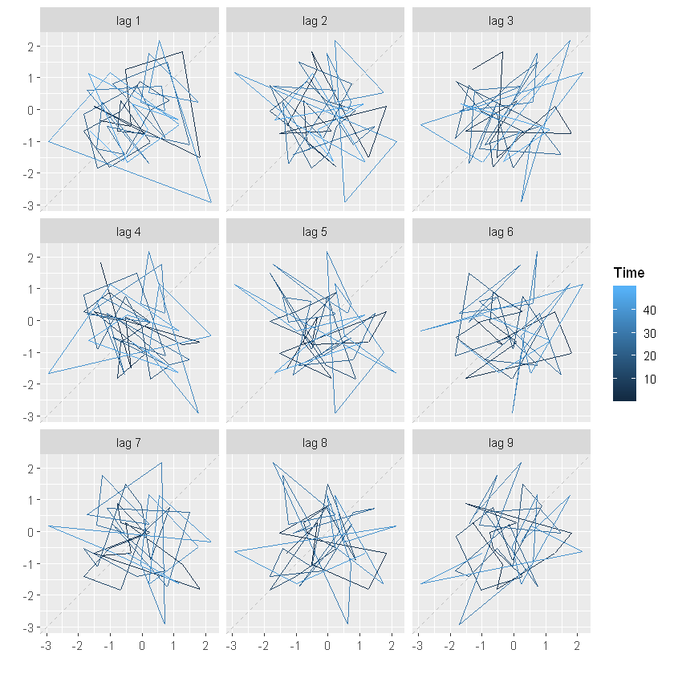

```r
gglagplot(y)
```

**Bibliografía**

- Forecasting: Principles and Practice Rob J Hyndman y George Athanasopoulos
- Machine Learning with R Cookbook - Second Edition 2017, by AshishSingh Bhatia, Chiu Yu-Wei, Packt Publishing.